# R Notebook

# Scottish Household Survey EDA

Read in the data

```r
library(tidyverse)
library(janitor)
library(here)
community_belonging <- read_csv(here::here("raw_data/community_belonging.csv")) %>%
  clean_names()
green_spaces <- read_csv(here::here("raw_data/green_spaces.csv")) %>%
  clean_names()
neighbourhood_rating <- read_csv(here::here("raw_data/neighbourhood_rating.csv")) %>%
  clean_names()
area_improvement <- read_csv(here::here("raw_data/area_improvement.csv")) %>%
  clean_names()
neighbourhood_involvement <- read_csv(here::here("raw_data/neighbourhood_involvement.csv")) %>%
  clean_names()
shs_responses <- read_csv(here::here("raw_data/shs_aggregate_responses.csv")) %>%
  clean_names()
```

### Community Belonging data

```r
glimpse(community_belonging)
```

```
## Rows: 43,611
## Columns: 13
## $ feature_code                           <chr> "S12000040", "S12000029", "S120…
## $ date_code                              <dbl> 2018, 2018, 2018, 2014, 2014, 2…
## $ measurement                            <chr> "95% Upper Confidence Limit, Pe…
## $ units                                  <chr> "Percent Of Adults", "Percent O…
## $ value                                  <dbl> 66.6, 29.3, 40.2, 50.9, 33.6, 4…
## $ community_belonging                    <chr> "Very strongly", "Very strongly…
## $ gender                                 <chr> "All", "All", "All", "All", "Al…
## $ urban_rural_classification             <chr> "All", "All", "All", "All", "Al…
## $ simd_quintiles                         <chr> "All", "All", "All", "All", "Al…
## $ type_of_tenure                         <chr> "All", "All", "All", "All", "Al…
## $ household_type                         <chr> "All", "All", "All", "All", "Al…
## $ ethnicity                              <chr> "All", "All", "All", "All", "Al…
## $ walking_distance_to_nearest_greenspace <chr> "More than 10 minutes", "More t…
```

```r
skimr::skim(community_belonging)
```

Data summary

| Name | community_belonging |
| --- | --- |
| Number of rows | 43611 |
| Number of columns | 13 |
| _______________________ |  |
| Column type frequency: |  |
| character | 11 |
| numeric | 2 |
| ________________________ |  |
| Group variables | None |

**Variable type: character**

| skim_variable | n_missing | complete_rate | min | max | empty | n_unique | whitespace |
| --- | --- | --- | --- | --- | --- | --- | --- |
| feature_code | 0 | 1 | 9 | 9 | 0 | 33 | 0 |
| measurement | 0 | 1 | 7 | 35 | 0 | 3 | 0 |
| units | 0 | 1 | 17 | 17 | 0 | 1 | 0 |
| community_belonging | 0 | 1 | 10 | 19 | 0 | 5 | 0 |
| gender | 0 | 1 | 3 | 6 | 0 | 3 | 0 |
| urban_rural_classification | 0 | 1 | 3 | 5 | 0 | 3 | 0 |
| simd_quintiles | 0 | 1 | 3 | 18 | 0 | 3 | 0 |
| type_of_tenure | 0 | 1 | 3 | 19 | 0 | 6 | 0 |
| household_type | 0 | 1 | 3 | 13 | 0 | 4 | 0 |
| ethnicity | 0 | 1 | 3 | 5 | 0 | 3 | 0 |
| walking_distance_to_nearest_greenspace | 0 | 1 | 3 | 20 | 0 | 4 | 0 |

**Variable type: numeric**

| skim_variable | n_missing | complete_rate | mean | sd | p0 | p25 | p50 | p75 | p100 | hist |
| --- | --- | --- | --- | --- | --- | --- | --- | --- | --- | --- |
| date_code | 0 | 1 | 2015.98 | 2.00 | 2013 | 2014.0 | 2016.0 | 2018.0 | 2019.0 | ▇▃▃▃▇ |
| value | 0 | 1 | 21.97 | 18.85 | 0 | 4.3 | 17.9 | 37.3 | 93.2 | ▇▃▃▁▁ |

> No missing values 11 character vectors and 2 numerical (`date_code` aka year, `value` aka percentage) columns of particular interest for business question: 1. `community_belonging` (answers to the question “how strongly do you feel you belong to your immediate neighbourhood?”) 2. `walking_distance_to_nearest_greenspace` (could change to a numeric with units in minutes) are both `measurement` and `units` columns needed? what does `feature_code` relate to? Local authority? Something else? personal attributes: `gender`, `ethnicity`, `simd_quintiles` household attributes: `household_type`, `type_of_tenure`, `urban_rural_classification` includes aggregated data (“All”)

```r
community_belonging %>%
  count(feature_code)
```

| feature_code | n |
| --- | --- |
| S12000005 | 1272 |
| S12000006 | 1182 |
| S12000008 | 1323 |
| S12000010 | 1299 |
| S12000011 | 1161 |
| S12000013 | 1089 |
| S12000014 | 1188 |
| S12000017 | 1338 |
| S12000018 | 1212 |
| S12000019 | 1161 |

[output cut: 23 more lines]

```r
community_belonging %>%
  count(gender)
```

| gender | n |
| --- | --- |
| All | 37242 |
| Female | 3192 |
| Male | 3177 |

```r
community_belonging %>%
  count(ethnicity)
```

| ethnicity | n |
| --- | --- |
| All | 40026 |
| Other | 261 |
| White | 3324 |

```r
community_belonging %>%
  count(walking_distance_to_nearest_greenspace)
```

| walking_distance_to_nearest_greenspace | n |
| --- | --- |
| All | 39375 |
| Don't Know | 105 |
| Less than 10 minutes | 3303 |
| More than 10 minutes | 828 |

```r
community_belonging %>%
  count(household_type)
```

| household_type | n |
| --- | --- |
| Adults | 3162 |
| All | 35223 |
| Pensioners | 2970 |
| With Children | 2256 |

```r
community_belonging %>%
  count(type_of_tenure)
```

| type_of_tenure | n |
| --- | --- |
| All | 35295 |
| Other | 105 |
| Owned Mortgage/Loan | 2592 |
| Owned Outright | 2949 |
| Private Rented | 534 |
| Social Rented | 2136 |

```r
community_belonging %>%
  count(community_belonging)
```

| community_belonging | n |
| --- | --- |
| Don't know | 5733 |
| Fairly strongly | 9564 |
| Not at all strongly | 9186 |
| Not very strongly | 9564 |
| Very strongly | 9564 |

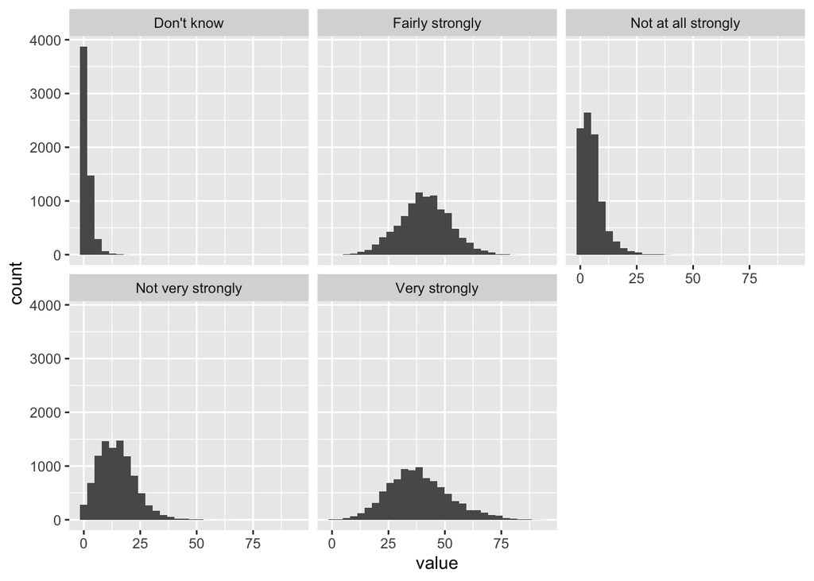

```r
community_belonging %>%
  ggplot() +
  geom_histogram(aes(value)) +
  facet_wrap(~ community_belonging)
```

### Greenspace data

```r
glimpse(green_spaces)
```

```
## Rows: 38,451
## Columns: 13
## $ feature_code                            <chr> "S12000026", "S12000045", "S12…
## $ date_code                               <dbl> 2013, 2017, 2014, 2017, 2017, …
## $ measurement                             <chr> "95% Lower Confidence Limit, P…
## $ units                                   <chr> "Percent Of Adults", "Percent …
## $ value                                   <dbl> 71.0, 59.0, 86.9, 80.9, 79.6, …
## $ distance_to_nearest_green_or_blue_space <chr> "A 5 minute walk or less", "A …
## $ age                                     <chr> "All", "All", "All", "All", "A…
## $ gender                                  <chr> "All", "All", "All", "All", "A…
## $ urban_rural_classification              <chr> "All", "All", "All", "All", "A…
## $ simd_quintiles                          <chr> "All", "All", "All", "All", "A…
## $ type_of_tenure                          <chr> "All", "All", "All", "All", "A…
## $ household_type                          <chr> "All", "Pensioners", "All", "A…
## $ ethnicity                               <chr> "All", "All", "All", "All", "A…
```

```r
skimr::skim(green_spaces)
```

Data summary

| Name | green_spaces |
| --- | --- |
| Number of rows | 38451 |
| Number of columns | 13 |
| _______________________ |  |
| Column type frequency: |  |
| character | 11 |
| numeric | 2 |
| ________________________ |  |
| Group variables | None |

**Variable type: character**

| skim_variable | n_missing | complete_rate | min | max | empty | n_unique | whitespace |
| --- | --- | --- | --- | --- | --- | --- | --- |
| feature_code | 0 | 1 | 9 | 9 | 0 | 33 | 0 |
| measurement | 0 | 1 | 7 | 35 | 0 | 3 | 0 |
| units | 0 | 1 | 17 | 17 | 0 | 1 | 0 |
| distance_to_nearest_green_or_blue_space | 0 | 1 | 10 | 25 | 0 | 4 | 0 |
| age | 0 | 1 | 3 | 17 | 0 | 4 | 0 |
| gender | 0 | 1 | 3 | 6 | 0 | 3 | 0 |
| urban_rural_classification | 0 | 1 | 3 | 5 | 0 | 3 | 0 |
| simd_quintiles | 0 | 1 | 3 | 18 | 0 | 3 | 0 |
| type_of_tenure | 0 | 1 | 3 | 19 | 0 | 6 | 0 |
| household_type | 0 | 1 | 3 | 13 | 0 | 4 | 0 |
| ethnicity | 0 | 1 | 3 | 5 | 0 | 3 | 0 |

**Variable type: numeric**

| skim_variable | n_missing | complete_rate | mean | sd | p0 | p25 | p50 | p75 | p100 | hist |
| --- | --- | --- | --- | --- | --- | --- | --- | --- | --- | --- |
| date_code | 0 | 1 | 2015.98 | 2.00 | 2013 | 2014.00 | 2016.0 | 2018.00 | 2019 | ▇▃▃▃▇ |
| value | 0 | 1 | 27.02 | 27.15 | 0 | 5.05 | 16.5 | 47.55 | 100 | ▇▂▁▂▁ |

> same format as community_belonging data (partial match?) added `age` column (grouped) `distance__to_nearest_green_or_blue_space` is now measured in percentage

```r
green_spaces %>%
  count(distance_to_nearest_green_or_blue_space)
```

| distance_to_nearest_green_or_blue_space | n |
| --- | --- |
| A 5 minute walk or less | 10377 |
| An 11 minute walk or more | 10350 |
| Don't Know | 7347 |
| Within a 6-10 minute walk | 10377 |

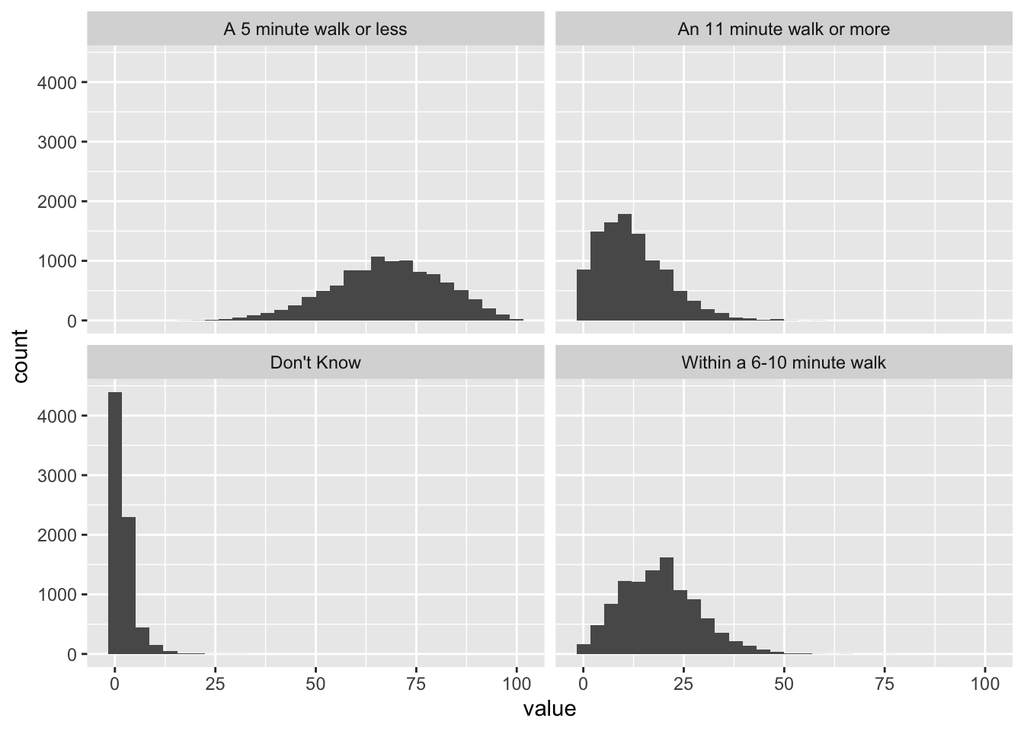

```r
green_spaces %>%
  ggplot() +
  geom_histogram(aes(value)) +
  facet_wrap(~ distance_to_nearest_green_or_blue_space)
```

```r
green_spaces %>%
  filter(value == 0)
```

| feature_code | date_code | measurement | units | value | distance_to_nearest_green_or_blue_space | age | gender | urban_rural_classification | simd_quintiles | type_of_tenure | household_type | ethnicity |
| --- | --- | --- | --- | --- | --- | --- | --- | --- | --- | --- | --- | --- |
| S12000036 | 2016 | 95% Lower Confidence Limit, Percent | Percent Of Adults | 0 | Don't Know | All | All | All | All | All | Pensioners | All |
| S12000041 | 2018 | 95% Lower Confidence Limit, Percent | Percent Of Adults | 0 | Don't Know | All | Female | All | All | All | All | All |
| S12000008 | 2018 | 95% Lower Confidence Limit, Percent | Percent Of Adults | 0 | Don't Know | All | Male | All | All | All | All | All |
| S12000045 | 2018 | 95% Lower Confidence Limit, Percent | Percent Of Adults | 0 | Don't Know | All | Male | All | All | All | All | All |
| S12000026 | 2018 | 95% Lower Confidence Limit, Percent | Percent Of Adults | 0 | Don't Know | All | All | All | All | All | All | All |
| S12000030 | 2018 | 95% Lower Confidence Limit, Percent | Percent Of Adults | 0 | Don't Know | All | All | All | All | All | All | All |
| S12000027 | 2018 | Percent | Percent Of Adults | 0 | Don't Know | All | All | All | All | All | All | All |
| S12000027 | 2018 | 95% Lower Confidence Limit, Percent | Percent Of Adults | 0 | Don't Know | All | All | All | All | All | All | All |
| S12000028 | 2018 | 95% Lower Confidence Limit, Percent | Percent Of Adults | 0 | Don't Know | All | All | All | All | All | All | All |
| S12000021 | 2016 | 95% Lower Confidence Limit, Percent | Percent Of Adults | 0 | Don't Know | All | All | Urban | All | All | All | All |

[output cut: 2542 more lines]

### Neighbourhood rating

```r
glimpse(neighbourhood_rating)
```

```
## Rows: 38,055
## Columns: 13
## $ feature_code                           <chr> "S12000033", "S12000039", "S120…
## $ date_code                              <dbl> 2018, 2016, 2016, 2013, 2018, 2…
## $ measurement                            <chr> "95% Lower Confidence Limit, Pe…
## $ units                                  <chr> "Percent Of Adults", "Percent O…
## $ value                                  <dbl> 34.2, 35.1, 63.3, 1.5, 11.9, 5.…
## $ neighbourhood_rating                   <chr> "Very good", "Very good", "Very…
## $ gender                                 <chr> "All", "All", "All", "All", "Al…
## $ urban_rural_classification             <chr> "All", "All", "All", "All", "Al…
## $ simd_quintiles                         <chr> "All", "All", "All", "All", "Al…
## $ type_of_tenure                         <chr> "All", "All", "All", "All", "Al…
## $ household_type                         <chr> "All", "All", "All", "All", "Al…
## $ ethnicity                              <chr> "All", "All", "All", "All", "Al…
## $ walking_distance_to_nearest_greenspace <chr> "More than 10 minutes", "More t…
```

```r
skimr::skim(neighbourhood_rating)
```

Data summary

| Name | neighbourhood_rating |
| --- | --- |
| Number of rows | 38055 |
| Number of columns | 13 |
| _______________________ |  |
| Column type frequency: |  |
| character | 11 |
| numeric | 2 |
| ________________________ |  |
| Group variables | None |

**Variable type: character**

| skim_variable | n_missing | complete_rate | min | max | empty | n_unique | whitespace |
| --- | --- | --- | --- | --- | --- | --- | --- |
| feature_code | 0 | 1 | 9 | 9 | 0 | 33 | 0 |
| measurement | 0 | 1 | 7 | 35 | 0 | 3 | 0 |
| units | 0 | 1 | 17 | 17 | 0 | 1 | 0 |
| neighbourhood_rating | 0 | 1 | 9 | 11 | 0 | 5 | 0 |
| gender | 0 | 1 | 3 | 6 | 0 | 3 | 0 |
| urban_rural_classification | 0 | 1 | 3 | 5 | 0 | 3 | 0 |
| simd_quintiles | 0 | 1 | 3 | 18 | 0 | 3 | 0 |
| type_of_tenure | 0 | 1 | 3 | 19 | 0 | 6 | 0 |
| household_type | 0 | 1 | 3 | 13 | 0 | 4 | 0 |
| ethnicity | 0 | 1 | 3 | 5 | 0 | 3 | 0 |
| walking_distance_to_nearest_greenspace | 0 | 1 | 3 | 20 | 0 | 4 | 0 |

**Variable type: numeric**

| skim_variable | n_missing | complete_rate | mean | sd | p0 | p25 | p50 | p75 | p100 | hist |
| --- | --- | --- | --- | --- | --- | --- | --- | --- | --- | --- |
| date_code | 0 | 1 | 2015.97 | 2.00 | 2013 | 2014.0 | 2016 | 2018.0 | 2019 | ▇▃▃▃▇ |
| value | 0 | 1 | 25.20 | 26.31 | 0 | 1.5 | 13 | 46.9 | 100 | ▇▂▃▂▁ |

> again, same format added `neighbourhood_rating` column

```r
# Trying to figure out what the measurement column pertains to
neighbourhood_rating %>%
  filter(feature_code == "S12000005" &
         date_code == 2013 &
         gender == "All" &
         urban_rural_classification == "All" &
         simd_quintiles == "All" &
         type_of_tenure == "All" &
         household_type == "All" &
         ethnicity == "All" &
         walking_distance_to_nearest_greenspace == "All") %>%
  group_by(measurement, neighbourhood_rating) %>%
  mutate(total_value = sum(value)) %>%
  select(value, total_value)
```

| measurement | neighbourhood_rating | value | total_value |
| --- | --- | --- | --- |
| Percent | Very poor | 3.0 | 3.0 |
| 95% Upper Confidence Limit, Percent | Fairly good | 55.5 | 55.5 |
| 95% Lower Confidence Limit, Percent | Fairly good | 42.0 | 42.0 |
| Percent | Fairly good | 49.0 | 49.0 |
| 95% Upper Confidence Limit, Percent | Fairly poor | 7.5 | 7.5 |
| Percent | Fairly poor | 5.0 | 5.0 |
| 95% Upper Confidence Limit, Percent | Very poor | 4.9 | 4.9 |
| 95% Lower Confidence Limit, Percent | Very poor | 0.6 | 0.6 |
| 95% Upper Confidence Limit, Percent | Very good | 50.3 | 50.3 |
| Percent | Very good | 44.0 | 44.0 |

[output cut: 2 more lines]

```r
neighbourhood_rating %>%
  count(walking_distance_to_nearest_greenspace)
```

| walking_distance_to_nearest_greenspace | n |
| --- | --- |
| All | 34254 |
| Don't Know | 102 |
| Less than 10 minutes | 2970 |
| More than 10 minutes | 729 |

```r
neighbourhood_rating %>%
  count(neighbourhood_rating)
```

| neighbourhood_rating | n |
| --- | --- |
| Fairly good | 9564 |
| Fairly poor | 8781 |
| No opinion | 3318 |
| Very good | 9564 |
| Very poor | 6828 |

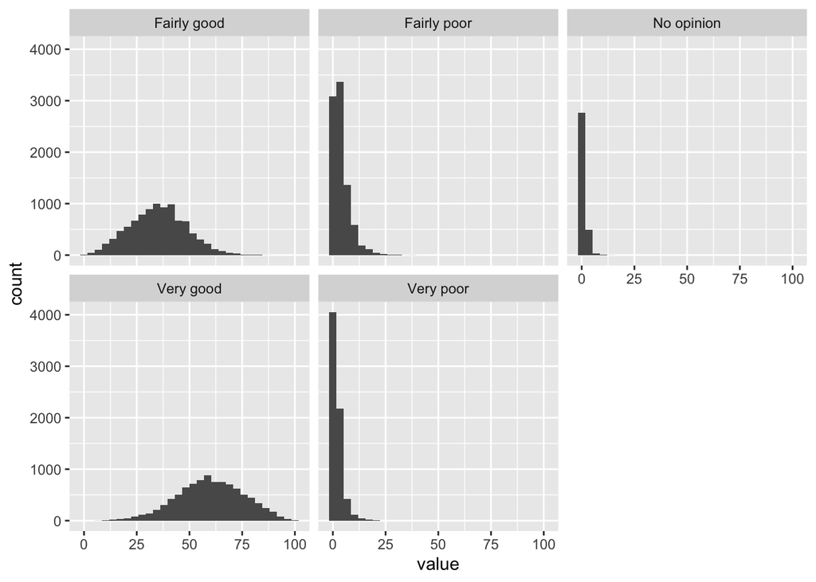

```r
neighbourhood_rating %>%
  ggplot() +
  geom_histogram(aes(value)) +
  facet_wrap(~ neighbourhood_rating)
```

```r
neighbourhood_rating %>%
  filter(value == 0)
```

| feature_code | date_code | measurement | units | value | neighbourhood_rating | gender | urban_rural_classification | simd_quintiles | type_of_tenure | household_type | ethnicity | walking_distance_to_nearest_greenspace |
| --- | --- | --- | --- | --- | --- | --- | --- | --- | --- | --- | --- | --- |
| S12000034 | 2019 | 95% Lower Confidence Limit, Percent | Percent Of Adults | 0 | Very poor | All | All | All | All | All | All | More than 10 minutes |
| S12000033 | 2013 | 95% Lower Confidence Limit, Percent | Percent Of Adults | 0 | Very poor | All | All | All | All | All | All | More than 10 minutes |
| S12000034 | 2019 | 95% Lower Confidence Limit, Percent | Percent Of Adults | 0 | Fairly poor | All | All | All | All | All | All | More than 10 minutes |
| S12000036 | 2014 | 95% Lower Confidence Limit, Percent | Percent Of Adults | 0 | Very poor | All | All | All | All | All | All | More than 10 minutes |
| S12000029 | 2019 | 95% Lower Confidence Limit, Percent | Percent Of Adults | 0 | Fairly poor | All | All | All | All | All | All | More than 10 minutes |
| S12000029 | 2017 | 95% Lower Confidence Limit, Percent | Percent Of Adults | 0 | Fairly poor | All | All | All | All | All | All | More than 10 minutes |
| S12000033 | 2017 | 95% Lower Confidence Limit, Percent | Percent Of Adults | 0 | Fairly poor | All | All | All | All | All | All | More than 10 minutes |
| S12000033 | 2019 | 95% Lower Confidence Limit, Percent | Percent Of Adults | 0 | Very poor | All | All | All | All | All | All | More than 10 minutes |
| S12000036 | 2015 | 95% Lower Confidence Limit, Percent | Percent Of Adults | 0 | Very poor | All | All | All | All | All | All | More than 10 minutes |
| S12000029 | 2014 | 95% Lower Confidence Limit, Percent | Percent Of Adults | 0 | Very poor | All | All | All | All | All | All | More than 10 minutes |

[output cut: 5109 more lines]

### Area Improvement

```r
glimpse(area_improvement)
```

```
## Rows: 47,805
## Columns: 15
## $ feature_code                           <chr> "S12000036", "S92000003", "S120…
## $ feature_name                           <chr> "City of Edinburgh", "Scotland"…
## $ feature_type                           <chr> "Council Area", "Country", "Cou…
## $ date_code                              <dbl> 2013, 2014, 2013, 2014, 2013, 2…
## $ measurement                            <chr> "95% Upper Confidence Limit, Pe…
## $ units                                  <chr> "Percent Of Adults", "Percent O…
## $ value                                  <dbl> 23.3, 5.0, 10.7, 88.4, 23.0, 4.…
## $ local_neighbourhood_improvement        <chr> "Neighbourhood a little worse",…
## $ gender                                 <chr> "All", "All", "All", "All", "Al…
## $ urban_rural_classification             <chr> "All", "All", "All", "All", "Al…
## $ simd_quintiles                         <chr> "All", "All", "All", "All", "Al…
## $ type_of_tenure                         <chr> "All", "All", "All", "All", "Al…
## $ household_type                         <chr> "All", "All", "All", "All", "Al…
## $ ethnicity                              <chr> "All", "All", "All", "All", "Al…
## $ walking_distance_to_nearest_greenspace <chr> "More than 10 minutes", "More t…
```

```r
skimr::skim(area_improvement)
```

Data summary

| Name | area_improvement |
| --- | --- |
| Number of rows | 47805 |
| Number of columns | 15 |
| _______________________ |  |
| Column type frequency: |  |
| character | 13 |
| numeric | 2 |
| ________________________ |  |
| Group variables | None |

**Variable type: character**

| skim_variable | n_missing | complete_rate | min | max | empty | n_unique | whitespace |
| --- | --- | --- | --- | --- | --- | --- | --- |
| feature_code | 0 | 1 | 9 | 9 | 0 | 33 | 0 |
| feature_name | 0 | 1 | 4 | 21 | 0 | 33 | 0 |
| feature_type | 0 | 1 | 7 | 12 | 0 | 2 | 0 |
| measurement | 0 | 1 | 7 | 35 | 0 | 3 | 0 |
| units | 0 | 1 | 17 | 17 | 0 | 1 | 0 |
| local_neighbourhood_improvement | 0 | 1 | 10 | 29 | 0 | 6 | 0 |
| gender | 0 | 1 | 3 | 6 | 0 | 3 | 0 |
| urban_rural_classification | 0 | 1 | 3 | 5 | 0 | 3 | 0 |
| simd_quintiles | 0 | 1 | 3 | 18 | 0 | 3 | 0 |
| type_of_tenure | 0 | 1 | 3 | 19 | 0 | 6 | 0 |
| household_type | 0 | 1 | 3 | 13 | 0 | 4 | 0 |
| ethnicity | 0 | 1 | 3 | 5 | 0 | 3 | 0 |
| walking_distance_to_nearest_greenspace | 0 | 1 | 3 | 20 | 0 | 4 | 0 |

**Variable type: numeric**

| skim_variable | n_missing | complete_rate | mean | sd | p0 | p25 | p50 | p75 | p100 | hist |
| --- | --- | --- | --- | --- | --- | --- | --- | --- | --- | --- |
| date_code | 0 | 1 | 2015.66 | 1.97 | 2013 | 2014.0 | 2016.0 | 2017 | 2019 | ▇▃▃▅▃ |
| value | 0 | 1 | 17.28 | 23.34 | 0 | 2.9 | 7.2 | 17 | 100 | ▇▁▁▁▁ |

> has additional feature_name and feature_type columns answers question whether selected adult thinks their area has improved

```r
area_improvement %>%
  count(local_neighbourhood_improvement) # what do differences in response nos mean? surely they should be recorded for all?
```

| local_neighbourhood_improvement | n |
| --- | --- |
| Don't Know | 7854 |
| Neighbourhood a little better | 8223 |
| Neighbourhood a little worse | 8217 |
| Neighbourhood much better | 7545 |
| Neighbourhood much worse | 7737 |
| Neighbourhood stayed the same | 8229 |

```r
area_improvement %>%
  count(feature_type)
```

| feature_type | n |
| --- | --- |
| Council Area | 45645 |
| Country | 2160 |

```r
area_improvement %>%
  count(feature_name)
```

| feature_name | n |
| --- | --- |
| Aberdeen City | 1497 |
| Aberdeenshire | 1473 |
| Angus | 1335 |
| Argyll and Bute | 1368 |
| City of Edinburgh | 1746 |
| Clackmannanshire | 1407 |
| Dumfries and Galloway | 1236 |
| Dundee City | 1371 |
| East Ayrshire | 1548 |
| East Dunbartonshire | 1254 |

[output cut: 23 more lines]

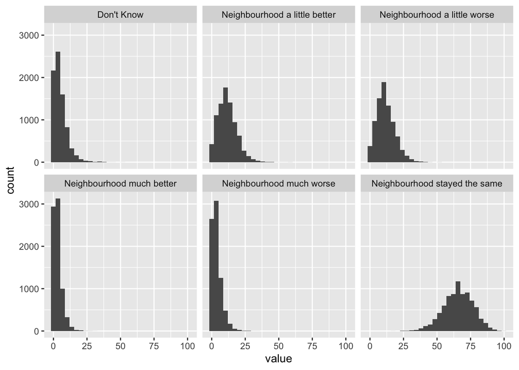

```r
area_improvement %>%
  ggplot() +
  geom_histogram(aes(value)) +
  facet_wrap(~ local_neighbourhood_improvement)
```

```r
area_improvement %>%
 filter(value == 0 & measurement == "Percent")
```

| feature_code | feature_name | feature_type | date_code | measurement | units | value | local_neighbourhood_improvement | gender | urban_rural_classification | simd_quintiles | type_of_tenure | household_type | ethnicity | walking_distance_to_nearest_greenspace |
| --- | --- | --- | --- | --- | --- | --- | --- | --- | --- | --- | --- | --- | --- | --- |
| S12000011 | East Renfrewshire | Council Area | 2016 | Percent | Percent Of Adults | 0 | Neighbourhood much worse | All | All | All | All | All | All | Less than 10 minutes |
| S12000027 | Shetland Islands | Council Area | 2013 | Percent | Percent Of Adults | 0 | Neighbourhood much better | All | All | All | All | All | All | Less than 10 minutes |
| S12000048 | Perth and Kinross | Council Area | 2013 | Percent | Percent Of Adults | 0 | Neighbourhood much better | All | All | All | All | All | All | Less than 10 minutes |
| S12000048 | Perth and Kinross | Council Area | 2017 | Percent | Percent Of Adults | 0 | Neighbourhood much worse | All | All | All | All | All | All | Less than 10 minutes |
| S12000048 | Perth and Kinross | Council Area | 2015 | Percent | Percent Of Adults | 0 | Neighbourhood much better | All | All | All | All | All | All | Less than 10 minutes |
| S12000030 | Stirling | Council Area | 2019 | Percent | Percent Of Adults | 0 | Neighbourhood much better | All | All | All | All | All | All | Less than 10 minutes |
| S12000023 | Orkney Islands | Council Area | 2014 | Percent | Percent Of Adults | 0 | Neighbourhood much worse | All | All | All | All | All | All | Less than 10 minutes |
| S12000023 | Orkney Islands | Council Area | 2015 | Percent | Percent Of Adults | 0 | Neighbourhood much worse | All | All | All | All | All | All | Less than 10 minutes |
| S12000048 | Perth and Kinross | Council Area | 2017 | Percent | Percent Of Adults | 0 | Neighbourhood much better | All | All | All | All | All | All | Less than 10 minutes |
| S12000027 | Shetland Islands | Council Area | 2015 | Percent | Percent Of Adults | 0 | Don't Know | All | All | All | All | All | All | Less than 10 minutes |

[output cut: 127 more lines]

### Neighbourhood Involvement

```r
glimpse(neighbourhood_involvement)
```

```
## Rows: 38,256
## Columns: 15
## $ feature_code                                 <chr> "S12000033", "S12000049",…
## $ feature_name                                 <chr> "Aberdeen City", "Glasgow…
## $ feature_type                                 <chr> "Council Area", "Council …
## $ date_code                                    <dbl> 2018, 2013, 2018, 2017, 2…
## $ measurement                                  <chr> "Percent", "95% Upper Con…
## $ units                                        <chr> "Percent Of Adults", "Per…
## $ value                                        <dbl> 65.0, 90.0, 51.6, 64.9, 7…
## $ involvement_with_people_in_the_neighbourhood <chr> "I can turn to people in …
## $ gender                                       <chr> "All", "All", "All", "All…
## $ urban_rural_classification                   <chr> "All", "All", "All", "All…
## $ simd_quintiles                               <chr> "All", "All", "All", "All…
## $ type_of_tenure                               <chr> "All", "All", "All", "All…
## $ household_type                               <chr> "All", "All", "All", "All…
## $ ethnicity                                    <chr> "All", "All", "All", "All…
## $ walking_distance_to_nearest_greenspace       <chr> "More than 10 minutes", "…
```

```r
skimr::skim(neighbourhood_involvement)
```

Data summary

| Name | neighbourhood_involvement |
| --- | --- |
| Number of rows | 38256 |
| Number of columns | 15 |
| _______________________ |  |
| Column type frequency: |  |
| character | 13 |
| numeric | 2 |
| ________________________ |  |
| Group variables | None |

**Variable type: character**

| skim_variable | n_missing | complete_rate | min | max | empty | n_unique | whitespace |
| --- | --- | --- | --- | --- | --- | --- | --- |
| feature_code | 0 | 1 | 9 | 9 | 0 | 33 | 0 |
| feature_name | 0 | 1 | 4 | 21 | 0 | 33 | 0 |
| feature_type | 0 | 1 | 7 | 12 | 0 | 2 | 0 |
| measurement | 0 | 1 | 7 | 35 | 0 | 3 | 0 |
| units | 0 | 1 | 17 | 17 | 0 | 1 | 0 |
| involvement_with_people_in_the_neighbourhood | 0 | 1 | 48 | 74 | 0 | 4 | 0 |
| gender | 0 | 1 | 3 | 6 | 0 | 3 | 0 |
| urban_rural_classification | 0 | 1 | 3 | 5 | 0 | 3 | 0 |
| simd_quintiles | 0 | 1 | 3 | 18 | 0 | 3 | 0 |
| type_of_tenure | 0 | 1 | 3 | 19 | 0 | 6 | 0 |
| household_type | 0 | 1 | 3 | 13 | 0 | 4 | 0 |
| ethnicity | 0 | 1 | 3 | 5 | 0 | 3 | 0 |
| walking_distance_to_nearest_greenspace | 0 | 1 | 3 | 20 | 0 | 4 | 0 |

**Variable type: numeric**

| skim_variable | n_missing | complete_rate | mean | sd | p0 | p25 | p50 | p75 | p100 | hist |
| --- | --- | --- | --- | --- | --- | --- | --- | --- | --- | --- |
| date_code | 0 | 1 | 2015.98 | 2.00 | 2013.0 | 2014.0 | 2016 | 2018.0 | 2019 | ▇▃▃▃▇ |
| value | 0 | 1 | 88.85 | 9.33 | 25.8 | 84.5 | 91 | 95.7 | 100 | ▁▁▁▂▇ |

> answers question to do with involvement with people in neighbourhood (how does this interact with neighbourhood_rating or community_belonging?)

```r
neighbourhood_involvement %>%
  count(involvement_with_people_in_the_neighbourhood)
```

| involvement_with_people_in_the_neighbourhood | n |
| --- | --- |
| I can rely on people in this neighbourhood to help me | 9564 |
| I can rely on people in this neighbourhood to look after my home when away | 9564 |
| I can turn to people in this neighbourhood for advice or support | 9564 |
| I would offer help to neighbours in an emergency | 9564 |

> there’s no negative framing of this question

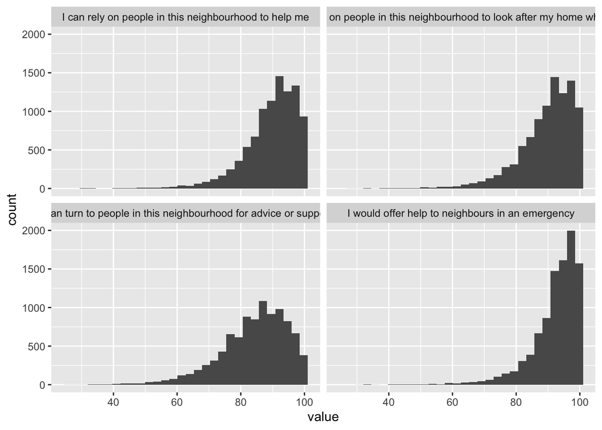

```r
neighbourhood_involvement %>%
  ggplot() +
  geom_histogram(aes(value)) +
  facet_wrap(~ involvement_with_people_in_the_neighbourhood)
```

### SHS aggregated responses

```r
glimpse(shs_responses)
```

```
## Rows: 58,530
## Columns: 13
## $ year                                  <dbl> 2012, 2012, 2012, 2012, 2012, 20…
## $ community_belonging                   <chr> "Don't know", "Don't know", "Don…
## $ neighbourhood_rating                  <chr> "Fairly good", "Fairly good", "F…
## $ distance_to_nearest_green_space       <chr> "A 5 minute walk or less", "A 5 …
## $ satisfaction_with_nearest_green_space <chr> "Fairly dissatisfied", "Fairly s…
## $ age                                   <chr> "35 - 64 Years", "16 - 34 Years"…
## $ gender                                <chr> "Female", "Female", "Female", "F…
## $ economic_status                       <chr> "Full Time Employment", "Full Ti…
## $ household_size                        <dbl> 3, 1, 2, 2, 2, 1, 2, 1, 1, 1, 1,…
## $ highest_education_level               <chr> "Degree, Professional qualificat…
## $ nearest_green_space_use               <chr> NA, NA, NA, NA, NA, NA, NA, NA, …
## $ volunteering_last_twelve_months       <chr> NA, NA, NA, NA, NA, NA, NA, NA, …
## $ n_persons                             <dbl> 1, 1, 1, 1, 1, 1, 1, 1, 1, 1, 1,…
```

```r
skimr::skim(shs_responses)
```

Data summary

| Name | shs_responses |
| --- | --- |
| Number of rows | 58530 |
| Number of columns | 13 |
| _______________________ |  |
| Column type frequency: |  |
| character | 10 |
| numeric | 3 |
| ________________________ |  |
| Group variables | None |

**Variable type: character**

| skim_variable | n_missing | complete_rate | min | max | empty | n_unique | whitespace |
| --- | --- | --- | --- | --- | --- | --- | --- |
| community_belonging | 0 | 1.00 | 10 | 19 | 0 | 5 | 0 |
| neighbourhood_rating | 0 | 1.00 | 9 | 11 | 0 | 5 | 0 |
| distance_to_nearest_green_space | 0 | 1.00 | 10 | 31 | 0 | 6 | 0 |
| satisfaction_with_nearest_green_space | 9988 | 0.83 | 10 | 34 | 0 | 6 | 0 |
| age | 0 | 1.00 | 10 | 13 | 0 | 3 | 0 |
| gender | 0 | 1.00 | 4 | 6 | 0 | 2 | 0 |
| economic_status | 1 | 1.00 | 5 | 20 | 0 | 6 | 0 |
| highest_education_level | 10920 | 0.81 | 19 | 54 | 0 | 5 | 0 |
| nearest_green_space_use | 16766 | 0.71 | 9 | 21 | 0 | 8 | 0 |
| volunteering_last_twelve_months | 6778 | 0.88 | 2 | 3 | 0 | 2 | 0 |

**Variable type: numeric**

| skim_variable | n_missing | complete_rate | mean | sd | p0 | p25 | p50 | p75 | p100 | hist |
| --- | --- | --- | --- | --- | --- | --- | --- | --- | --- | --- |
| year | 0 | 1 | 2015.35 | 2.27 | 2012 | 2013 | 2015 | 2017 | 2019 | ▇▅▇▂▆ |
| household_size | 0 | 1 | 2.18 | 1.19 | 1 | 1 | 2 | 3 | 10 | ▇▃▁▁▁ |
| n_persons | 0 | 1 | 1.31 | 1.45 | 1 | 1 | 1 | 1 | 94 | ▇▁▁▁▁ |

> quite a lot of missing values in `satisfaction_with_nearest_green_space`, `highest_education_level`, `nearest_green_space_use`, `volunteering_last_twelve_months` (and 1 in `economic_status`) 1 most common `n_persons` value age is categorical/factor

```r
shs_responses %>%
  count(n_persons)
```

| n_persons | n |
| --- | --- |
| 1 | 50346 |
| 2 | 4928 |
| 3 | 1493 |
| 4 | 623 |
| 5 | 368 |
| 6 | 214 |
| 7 | 132 |
| 8 | 100 |
| 9 | 58 |
| 10 | 51 |

[output cut: 33 more lines]

```r
shs_responses %>%
  count(satisfaction_with_nearest_green_space)
```

| satisfaction_with_nearest_green_space | n |
| --- | --- |
| Fairly dissatisfied | 3002 |
| Fairly satisfied | 19100 |
| Neither satisfied nor dissatisfied | 4944 |
| No opinion | 3418 |
| Very dissatisfied | 1658 |
| Very satisfied | 16420 |
| NA | 9988 |

```r
shs_responses %>%
  count(highest_education_level)
```

| highest_education_level | n |
| --- | --- |
| Degree, Professional qualification (Above SVQ Level 4) | 15940 |
| Higher, A level or equivalent (SVQ Level 3) | 9790 |
| HNC/HND or equivalent (SVQ Level 4) | 7144 |
| Other qualification | 3062 |
| Standard grade or equiv (SVQ level 1 or 2). | 11674 |
| NA | 10920 |

```r
shs_responses %>%
  count(volunteering_last_twelve_months)
```

| volunteering_last_twelve_months | n |
| --- | --- |
| No | 36934 |
| Yes | 14818 |
| NA | 6778 |

```r
shs_responses %>%
  filter(is.na(satisfaction_with_nearest_green_space) & is.na(nearest_green_space_use)) %>%
  count(year)
```

| year | n |
| --- | --- |
| 2017 | 5080 |
| 2018 | 4908 |

```r
shs_responses %>%
  count(year)
```

| year | n |
| --- | --- |
| 2012 | 6778 |
| 2013 | 8563 |
| 2014 | 8388 |
| 2015 | 8168 |
| 2016 | 8309 |
| 2017 | 5080 |
| 2018 | 4908 |
| 2019 | 8336 |

> looks like greenspace questions were not asked in 2017 or 2018

```r
shs_responses %>%
  filter(is.na(volunteering_last_twelve_months)) %>%
  count(year)
```

| year | n |
| --- | --- |
| 2012 | 6778 |

> volunteering was left out of 2012 survey

```r
shs_responses %>%
  filter(is.na(highest_education_level)) %>%
  count(year)
```

| year | n |
| --- | --- |
| 2012 | 1430 |
| 2013 | 1764 |
| 2014 | 1648 |
| 2015 | 1518 |
| 2016 | 1529 |
| 2017 | 868 |
| 2018 | 781 |
| 2019 | 1382 |

> `highest_education_level` has more of an unstructered nature to NAs

```r
shs_responses %>%
  filter(n_persons > 1) %>%
  count(year)
```

| year | n |
| --- | --- |
| 2012 | 1339 |
| 2013 | 752 |
| 2014 | 763 |
| 2015 | 720 |
| 2016 | 750 |
| 2017 | 1549 |
| 2018 | 1533 |
| 2019 | 778 |

> if limiting data to responses of individuals lose high proportion of data from 2012/17/18 2012 would be 80% complete 2017 and 2018 would be roughly 69% complete Is it worth it?